# Relationship of Cedar City Aquatic Center Admission Fees and Temperature

James Andersen

# Introduction

This works investigates the relationship of fees collected at the Cedar City Aquatic Center and the mean daily temperature in Cedar City. An instinctive insight is that as the temperature increases more people will go to the Aquatic Center and thus the fees collected will have a positive relationship with mean temperature. This is primarily just a practice exercise in using/learning R to validate and visualize the relationship.

## Source Data Preparation

### Aquatic Center Fees

Data from the Cedar City Aquatic center is collected from the Utah Public Finance website [^1] pulling the Revenue and filtering to the “AQUATIC CENTER” fund and the “FEE-ADMISSIONS” sub-category.

```r
# Handle non-standard date format
setClass('myDate')
setAs("character","myDate", function(from) as.Date(from, format="%m/%d/%Y"))

revClasses <- c("POSTING.DATE"="myDate")
rev <- rbind(
  read.csv("CedarCity_Revenue_2013.csv", header = TRUE, colClasses = revClasses),
  read.csv("CedarCity_Revenue_2014.csv", header = TRUE, colClasses = revClasses),
  read.csv("CedarCity_Revenue_2015.csv", header = TRUE, colClasses = revClasses),
  read.csv("CedarCity_Revenue_2016.csv", header = TRUE, colClasses = revClasses)
)
```

The dplyr library is used to filter and sum up multiple admission fees by day as well as rename the “POSTING.DATA” column to simply “date”.

```r
aquaticCenterFees <- rev %>%
  filter(FUND1 == "AQUATIC CENTER", CAT2 == "FEES-ADMISSIONS") %>%
  select(date = POSTING.DATE, AMOUNT) %>%
  group_by(date) %>%
  summarise(fees = sum(AMOUNT))
```

### Temperature Data

The temperature data used in the analysis comes from [Weather Underground](https://www.wunderground.com) which offers a historical weather API from which daily weather stats can be downloaded in chunks of about a year at a time. For this project 5 data files covering the range of aquatic center data were obtained and concatenated together.

```r
weather <- rbind(
  read.csv("CedarCity_Weather1.csv", header = TRUE, colClasses = c("MST"="Date")),
  read.csv("CedarCity_Weather2.csv", header = TRUE, colClasses = c("MST"="Date")),
  read.csv("CedarCity_Weather3.csv", header = TRUE, colClasses = c("MST"="Date")),
  read.csv("CedarCity_Weather4.csv", header = TRUE, colClasses = c("MST"="Date")),
  read.csv("CedarCity_Weather5.csv", header = TRUE, colClasses = c("MST"="Date"))
)
```

Again, dplyr is used to trim out several columns of data we’re not using and to rename the “MST” date field to “date”.

```r
meanTemp <- weather %>%
  select(date = MST, temp = Mean.TemperatureF, precip = PrecipitationIn)
```

### Combining Data and Final Prep

The two data sources are combined into a single data frame by joining on the date and a week column is added which aids in binning the data for a less noisy visual presentation.

```r
data <- merge(meanTemp, aquaticCenterFees, by="date", all = TRUE)
data$week <- as.Date(cut(data$date, breaks = "week", start.on.monday = FALSE))
data$year <- format(data$date,"%Y")
```

## Data Visualization

To give a sense of the data through time, the week bins are used to plot both the admission fees and temperature through time.

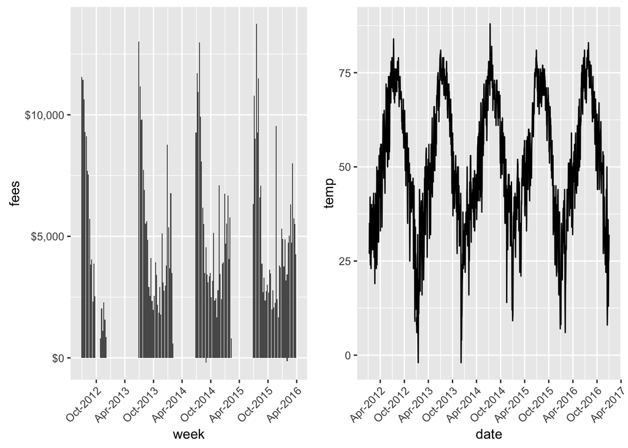

```r
library(ggplot2)
library(gridExtra)
feesPlot <- ggplot(data = data, aes(week , fees)) +
  geom_bar(stat = "identity") +
  scale_y_continuous(labels = scales::dollar) +
  scale_x_date(date_breaks = "6 months", date_labels = "%b-%Y") +
  theme(axis.text.x = element_text(angle = 45, hjust = 1))

tempPlot <- ggplot(data = data, aes(date, temp)) +
  geom_line(aes(group = year), stat = "identity") +
  scale_x_date(date_breaks = "6 months", date_labels = "%b-%Y") +
  theme(axis.text.x = element_text(angle = 45, hjust = 1))

grid.arrange(feesPlot, tempPlot, ncol=2)
```

To begin to visualize the relationship of temperature and admission fees, the two are shown together in a scatterplot.

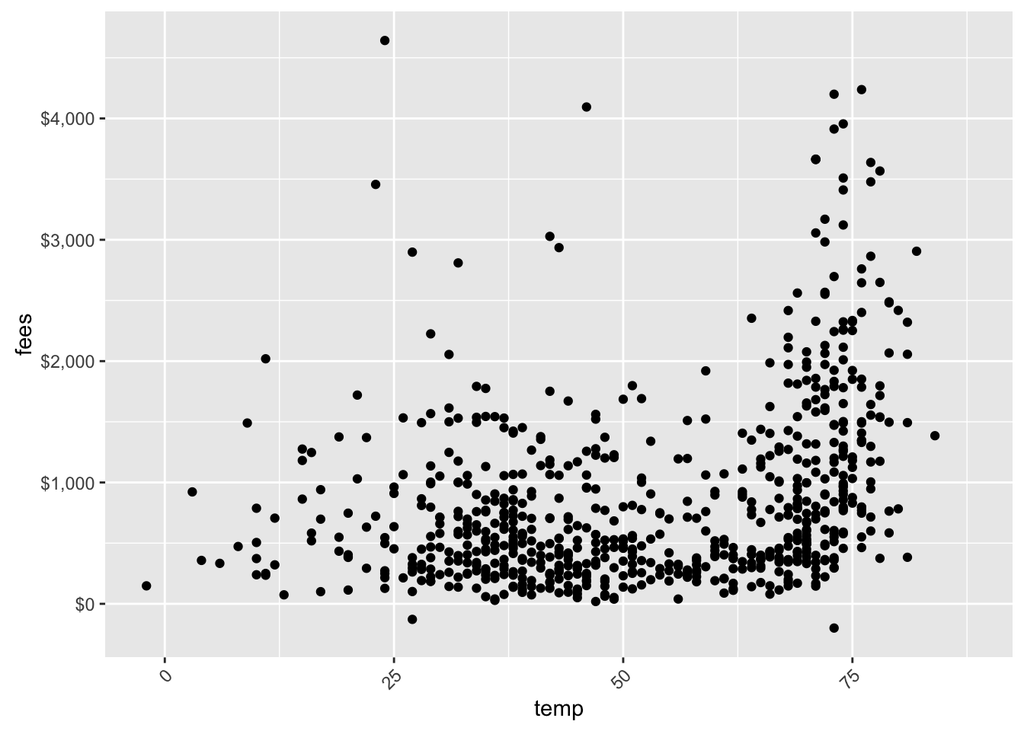

```r
ggplot(data = data, aes(temp, fees)) +
  geom_point(stat = "identity") +
  #geom_line(data=data, aes(x=date, y=precip), colour="blue") +
  scale_y_continuous(labels = scales::dollar) +
  theme(axis.text.x = element_text(angle = 45, hjust = 1))
```

## Significance of the Relationship

### Pearson Correlation

R’s `cor.test` evaluates the null and alternative hypothesis:

```r
cor.test(data$temp, data$fees, use="pairwise", method="pearson")
```

```
##
##  Pearson's product-moment correlation
##
## data:  data$temp and data$fees
## t = 8.8003, df = 717, p-value < 2.2e-16
## alternative hypothesis: true correlation is not equal to 0
## 95 percent confidence interval:
##  0.2446932 0.3767399
## sample estimates:
##       cor
## 0.3122238
```

We can perform a simple linear regression and determine the coefficients of the relationship.

```r
coef(lm(fees ~ temp, data = data))
```

```
## (Intercept)        temp
##   193.22932    12.90754
```

And having shown the relationship to be significant, we can visualize the trend:

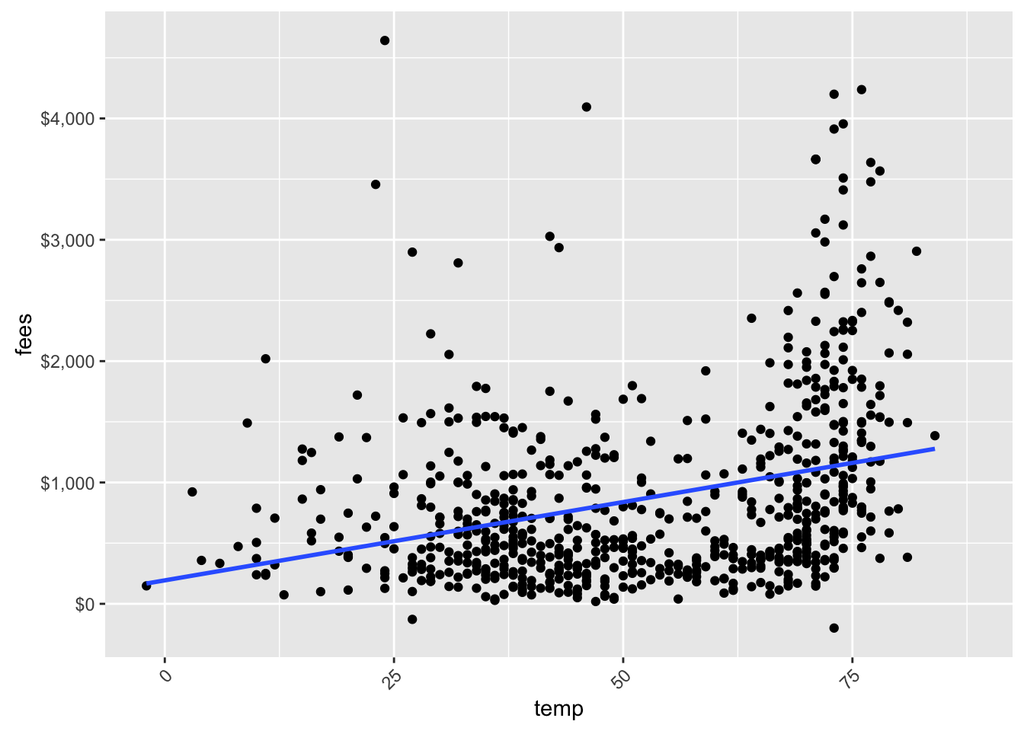

```r
ggplot(data = data, aes(temp, fees)) +
  geom_point(stat = "identity") +
  geom_smooth(method = "lm", se = FALSE) +
  scale_y_continuous(labels = scales::dollar) +
  theme(axis.text.x = element_text(angle = 45, hjust = 1))
```

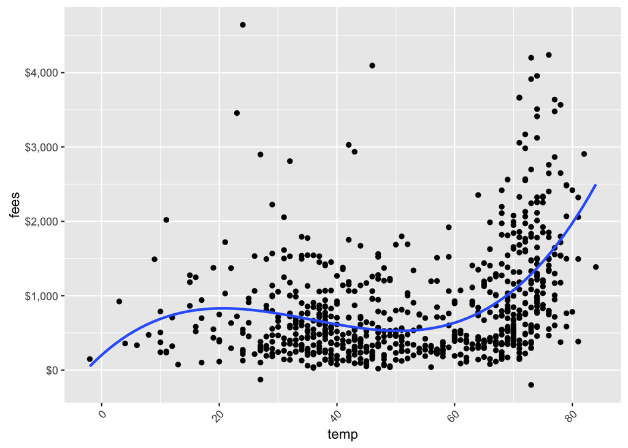

```r
data <- merge(meanTemp, aquaticCenterFees, by="date")
ggplot(data = data, aes(temp, fees)) +
  geom_point(stat = "identity") + geom_smooth(method = "lm", formula = y ~ x + I(x^2) + I(x^3), se = FALSE, data = data) +
  scale_y_continuous(labels = scales::dollar) +
  theme(axis.text.x = element_text(angle = 45, hjust = 1))
```

[^1]: Note that data appears to be truncated at about 10,000 records per year. I’ve requested a full dataset but have not yet received the data.